# Comandos básicos en R

Por: Fernanda Rabanal e Isabel Ruiz

2025-05-28

Antes de inciar debe definir la ubicación de su carpeta de trabajo o archivos con el comando `setwd()`, lo que le permitirá acceder más fácilmente a los archivos a trabajar. Nota: esta acción también puede ser definida por medio de las pestañas en la parte superior *Session > Set Working Directory > Choose Directory*. Se recomienda tener todos los archivos a utilizar en una sola carpeta junto con sus scripts para facilitar la ejecución de los comandos.

# Introducción al uso de R

### ¿Qué puedo hacer con R?

#### Cálculos matemáticos

```r
1+1
```

```
## [1] 2
```

```r
(1+4)/2
```

```
## [1] 2.5
```

#### Podemos almacenar información numérica en **variables** y realizar cálculos con ellas

```r
a <- 1
b <- 4
c <- 2

a+a
```

```
## [1] 2
```

```r
#También podemos añadir anotaciones

#Realizar cálculo de variables

(a+b)/c
```

```
## [1] 2.5
```

```r
#Podemos almacenar variables con "<-" o con "="

ejemplo1 <- a+a
ejemplo2 = (a+b)/c

#Al mencionar la variable de nuestro, podemos ver el resultado almacenado en esta
ejemplo1
```

```
## [1] 2
```

```r
ejemplo2
```

```
## [1] 2.5
```

También podemos trabajar con texto

```r
X1 <- "Nombre"
X2 <- "Apellido"

#paste concatena las variables
ejemplo3 <- paste(X1, X2)
ejemplo3
```

```
## [1] "Nombre Apellido"
```

Podemos definir **vectores**

```r
x <- c(1,2,3,4)
variables <- c("integer", "numeric","character","logical", "factor")
example <- c(100,0.05, "hello", TRUE, "Green")
```

Que nos permitirán construir bases de datos

```r
tipos_variables <- data.frame(
  Variables = variables,
  Example1 = example,
  Example2 = c(55, -0.56, "world", FALSE, "Blue")
)

#Nota: los objetos en R son estructuras de datos especializadas como variables, vectores, matrices, listas, bases de datos, entre otros.
```

| Variables | Example1 | Example2 |
| --- | --- | --- |
| integer | 100 | 55 |
| numeric | 0.05 | -0.56 |
| character | hello | world |
| logical | TRUE | FALSE |
| factor | Green | Blue |

También podemos describir la base de datos construida

```r
#nombre columnas
colnames(tipos_variables)
```

```
## [1] "Variables" "Example1"  "Example2"
```

```r
#nombre de las filas
rownames(tipos_variables)
```

```
## [1] "1" "2" "3" "4" "5"
```

```r
#Número de columnas
ncol(tipos_variables)
```

```
## [1] 3
```

```r
#Número de filas
nrow(tipos_variables)
```

```
## [1] 5
```

#### También podemos realizar cáculos a partir de la información en una base de datos.

Para este ejemplo usaremos la base de datos *cars*, una base de datos predeterminada en R.

Velocidad y distancia alcanzada por un automóvil. Nota: Solo se muestran las primeras cinco entradas.

| speed | dist |
| --- | --- |
| 4 | 2 |
| 4 | 10 |
| 7 | 4 |
| 7 | 22 |
| 8 | 16 |

Podemos calcular el promedio de la velocidad

```r
#funcion(data.frame$colname)
mean(cars$speed)
```

```
## [1] 15.4
```

También podemos generar un nuevo valor a partir de las columnas mostradas y añadirla a la base de datos

```r
# Calcular nuevos valores a partir de las columnas mostradas
time <- cars$dist / cars$speed

#Añadirla a la base de datos
cars$time <- time
```

Velocidad, distancia y tiempo alcanzada por un automóvil. Nota: Solo se muestran las primeras cinco entradas.

| speed | dist | time |
| --- | --- | --- |
| 4 | 2 | 0.5000000 |
| 4 | 10 | 2.5000000 |
| 7 | 4 | 0.5714286 |
| 7 | 22 | 3.1428571 |
| 8 | 16 | 2.0000000 |

Resumir datos de las bases de datos

```r
summary(cars)
```

```
##      speed           dist             time
##  Min.   : 4.0   Min.   :  2.00   Min.   :0.500
##  1st Qu.:12.0   1st Qu.: 26.00   1st Qu.:1.921
##  Median :15.0   Median : 36.00   Median :2.523
##  Mean   :15.4   Mean   : 42.98   Mean   :2.632
##  3rd Qu.:19.0   3rd Qu.: 56.00   3rd Qu.:3.186
##  Max.   :25.0   Max.   :120.00   Max.   :5.714
```

Podemos elaborar gráficos

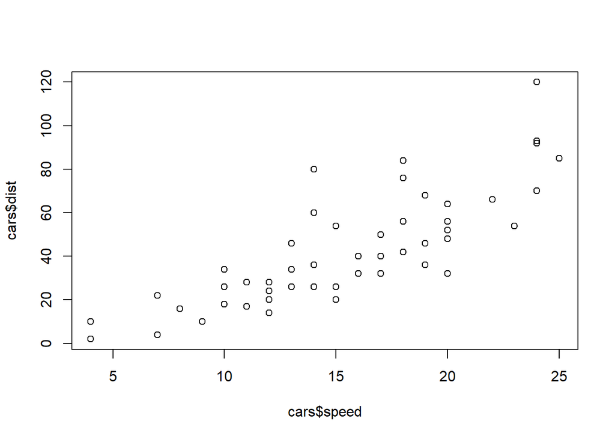

```r
plot(cars$speed, cars$dist)
```

#### Comando para cargar bases de datos

También puede ser definido por medio de las ventana de *Environment*, ir a *Import Dataset>From text*, o la opción que sea más conveniente, y luego verificar que se esté importando en el formato correcto. Luego, dar en *Aceptar*.

```r
altura <- read.csv("mean-height-males-vs-females.csv")
```

Altura promedio de hombres y mujeres en el Perú por año (1896 - 1996). Nota: Solo se muestran las primeras cinco entradas.

| Entity | Year | Mean_male_height_.cm. | Mean_female_height_.cm. |
| --- | --- | --- | --- |
| Peru | 1896 | 154.9275 | 141.4818 |
| Peru | 1897 | 155.0537 | 141.6709 |
| Peru | 1898 | 155.1801 | 141.8603 |
| Peru | 1899 | 155.3065 | 142.0496 |
| Peru | 1900 | 155.4331 | 142.2386 |

**Ejercicio 01** Calcular la diferencia entre la altura promedio de hombres y mujeres. Luego, añadirla a la base de datos “altura”

```r
#Cálculo de la diferencia de altura entre hombres y mujeres
Diferencia <- altura$Mean_male_height_.cm. - altura$Mean_female_height_.cm.
#Almacena la diferencia de altura en una nueva columna
altura$Diferencia <- Diferencia

kable(head(altura,5), caption = "Base de datos actualizada. Nota: Solo se muestran las primeras cinco entradas.")
```

Base de datos actualizada. Nota: Solo se muestran las primeras cinco entradas.

| Entity | Year | Mean_male_height_.cm. | Mean_female_height_.cm. | Diferencia |
| --- | --- | --- | --- | --- |
| Peru | 1896 | 154.9275 | 141.4818 | 13.44576 |
| Peru | 1897 | 155.0537 | 141.6709 | 13.38284 |
| Peru | 1898 | 155.1801 | 141.8603 | 13.31984 |
| Peru | 1899 | 155.3065 | 142.0496 | 13.25698 |
| Peru | 1900 | 155.4331 | 142.2386 | 13.19446 |

**Ejercicio 02** Elaborar un gráfico que muestre el año y la diferencia calculada

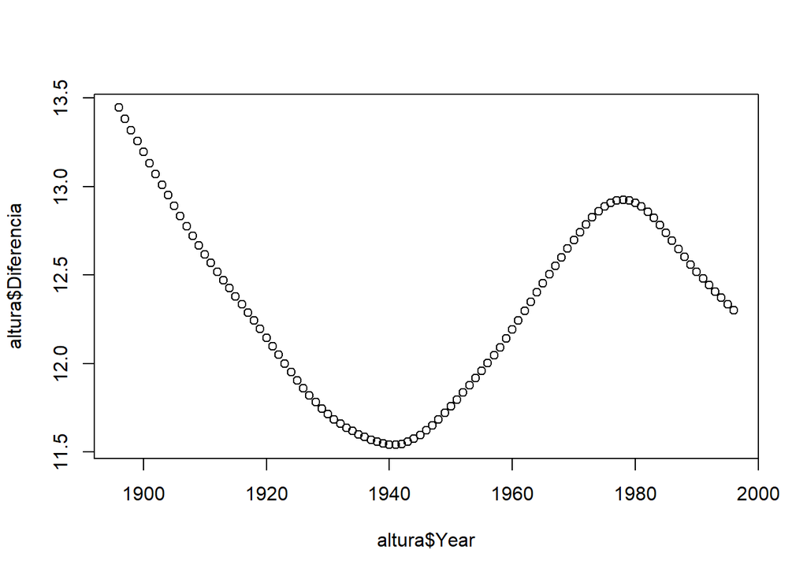

```r
plot(altura$Year, altura$Diferencia)
```

```r
#Nota: El gráfico aún se puede mejorar para lograr estándares de publicación tras modificar los ejes, y añadiendo un título de un gráfico.
```

#### Exportar archivos

```r
write.csv(altura, "altura.csv")
```

### Funciones

¿Recuerdan “mean”, “summary” o “plot”? Todas ellas son funciones que nos permiten realizar cálculos o elaborar gráficos por medio de un solo comando, pero detrás de cada una de ellas ocurre una serie de cálculos o transformaciones.

Algunas se encuentran predeterminadas en R, otras pueden ser instaladas por medio de paquetes (*packages*) y almacenadas en el computador en una biblioteca (*library*) y, en algunos casos, pueden ser definidos por el usuario. Actualmente, están disponible una gran cantidad de paquetes específicos para análisis biológicos como *ape*, *phytools*, entre otros. En la siguiente sección, veremos algunos de ellos.

En la imagen, se detalla la estructura para definir una función.

[figure not shown]

Estructura de una función (Autor: Learn by Example)

### Enlaces recomendados

[R Manuals](https://rstudio.github.io/r-manuals/r-lang/)

[Posit Cheatsheets](https://posit.co/resources/cheatsheets/)